# Get started with open reproducible science!

[Open reproducible science](https://www.earthdatascience.org/courses/intro-to-earth-data-science/open-reproducible-science/get-started-open-reproducible-science/) makes scientific methods, data and outcomes available to everyone. That means that *everyone* who wants should be able to **find**, **read**, **understand**, and **run** your workflows for themselves.

[figure not shown]

> Image from https://www.earthdata.nasa.gov/esds/open-science/oss-for-eso-workshops

Few if any science projects are 100% open and reproducible (yet!). However, members of the open science community have developed open source tools and practices that can help you move toward that goal. You will learn about many of those tools in [the Intro to Earth Data Science textbook](https://www.earthdatascience.org/courses/intro-to-earth-data-science/). Don't worry about learning all the tools at once -- we've picked a few for you to get started with.

```python
# Import pandas package
import pandas as pd
```

Once you have run the cell above and imported `pandas`, **run the cell below**. It is a test cell that will tell you if you completed the task successfully. If a test cell isn't working the way you expect, check that you ran your code **immediately before** running the test.

```python
# DO NOT MODIFY THIS TEST CELL
points = 0
try:
    pd.DataFrame()
    points += 5
    print('\u2705 Great work! You correctly imported the pandas library.')
except:
    print('\u274C Oops - pandas was not imported correctly.')
print('You earned {} of 5 points for importing pandas'.format(points))
```

```
✅ Great work! You correctly imported the pandas library.
You earned 5 of 5 points for importing pandas
```

```python
source_url =('https://www.ncei.noaa.gov/access/monitoring/'
             'climate-at-a-glance/global/time-series/globe/land_ocean/'
             '1/12/1850-2023/data.csv')
source_url
```

```
'https://www.ncei.noaa.gov/access/monitoring/climate-at-a-glance/global/time-series/globe/land_ocean/1/12/1850-2023/data.csv'
```

```python
# DO NOT MODIFY THIS TEST CELL
resp_url = _
points = 0

if type(resp_url)==str:
    points += 3
    print('\u2705 Great work! You correctly called your url variable.')
else:
    print('\u274C Oops - your url variable was not called correctly.')

if len(resp_url)<=123:
    points += 3
    print('\u2705 Great work! Your url is the correct length.')
else:
    print('\u274C Oops - your url variable is not the correct length.')

print('You earned {} of 6 points for defining a url variable'.format(points))
```

```
✅ Great work! You correctly called your url variable.
✅ Great work! Your url is the correct length.
You earned 6 of 6 points for defining a url variable
```

```python
dataframe = pd.read_csv(source_url, header=4, names=['Date', 'TempAnomaly[C]'])
dataframe
```

|  | Date | TempAnomaly[C] |
| --- | --- | --- |
| 0 | 1850 | -0.07 |
| 1 | 1851 | -0.03 |
| 2 | 1852 | -0.09 |
| 3 | 1853 | -0.22 |
| 4 | 1854 | 0.01 |
| ... | ... | ... |
| 169 | 2019 | 1.10 |
| 170 | 2020 | 0.84 |
| 171 | 2021 | 0.87 |
| 172 | 2022 | 0.84 |
| 173 | 2023 | 1.43 |

174 rows × 2 columns

```python
# DO NOT MODIFY THIS TEST CELL
tmax_df_resp = _
points = 0

if isinstance(tmax_df_resp, pd.DataFrame):
    points += 1
    print('\u2705 Great work! You called a DataFrame.')
else:
    print('\u274C Oops - make sure to call your DataFrame for testing.')

summary = [round(val, 17) for val in tmax_df_resp.mean().values]
if summary == [1936.0, 0.04375722543352601]:
    points += 4
    print('\u2705 Great work! You correctly downloaded data.')
else:
    print('\u274C Oops - your data are not correct.')
print('You earned {} of 5 points for downloading data'.format(points))
```

```
✅ Great work! You called a DataFrame.
❌ Oops - your data are not correct.
You earned 1 of 5 points for downloading data
```

> HINT: Check out the `type()` function below - you can use it to check that your data is now in `DataFrame` type object

```python
# Check that the data was imported into a pandas DataFrame
type(dataframe)
```

```
pandas.core.frame.DataFrame
```

Want an EXTRA CHALLENGE? Modify the code to be **more expressive**.

Rewrite the code below to select columns by **name** instead of by **index**. You might find the [pandas User Guide section on slicing and dicing](https://pandas.pydata.org/docs/user_guide/indexing.html) to be useful. However - don't worry if you can't figure this out yet! We're going to talk a lot about how to use pandas `DataFrame`s.

```python
#convert to fahrenheit
dataframe['TempAnomaly[F]'] = (dataframe.iloc[:,1] *1.8) + 32
dataframe
```

|  | Date | TempAnomaly[C] | TempAnomaly[F] |
| --- | --- | --- | --- |
| 0 | 1850 | -0.07 | 31.874 |
| 1 | 1851 | -0.03 | 31.946 |
| 2 | 1852 | -0.09 | 31.838 |
| 3 | 1853 | -0.22 | 31.604 |
| 4 | 1854 | 0.01 | 32.018 |
| ... | ... | ... | ... |
| 169 | 2019 | 1.10 | 33.980 |
| 170 | 2020 | 0.84 | 33.512 |
| 171 | 2021 | 0.87 | 33.566 |
| 172 | 2022 | 0.84 | 33.512 |
| 173 | 2023 | 1.43 | 34.574 |

174 rows × 3 columns

```python
# DO NOT MODIFY THIS TEST CELL
tmax_df_resp = _
points = 0

if isinstance(tmax_df_resp, pd.DataFrame):
    points += 1
    print('\u2705 Great work! You called a DataFrame.')
else:
    print('\u274C Oops - make sure to call your DataFrame for testing.')

summary = [round(val, 17) for val in tmax_df_resp.mean().values]
if summary == [1936.0, 0.04375722543352601, 32.078763005780345]:
    points += 4
    print('\u2705 Great work! You correctly converted to Celcius.')
else:
    print('\u274C Oops - your data are not correct.')
print('You earned {} of 5 points for converting to Celcius'.format(points))
```

```
✅ Great work! You called a DataFrame.
❌ Oops - your data are not correct.
You earned 1 of 5 points for converting to Celcius
```

Want an **EXTRA CHALLENGE**?

1. As you did above, rewrite the code to be more expressive
2. Using the code below as a framework, write and apply a **function** that converts to Celcius.

   > **Functions** let you reuse code you have already written
3. You should also rewrite this function name to be more expressive.

   ```
   def convert(temperature):
       """Convert temperature to Celcius"""
       return temperature # Put your equation in here

   dataframe['temp_c'] = dataframe['temp_f'].apply(convert)
   ```

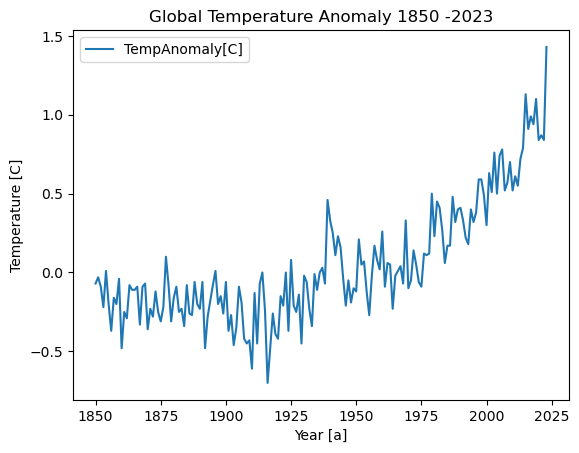

```python
dataframe.plot(x='Date', y='TempAnomaly[C]',
               title='Global Temperature Anomaly 1850 -2023',
                ylabel= 'Temperature [C]', xlabel= 'Year [a]' )
#testcanhe
```

[figure not shown]

> Image source: https://www.nps.gov/pais/learn/nature/hatchlingreleases.htm

Want an **EXTRA CHALLENGE**?

There are many other things you can do to customize your plot. Take a look at the [pandas plotting galleries](https://pandas.pydata.org/docs/user_guide/visualization.html) and the [documentation of plot](https://pandas.pydata.org/docs/reference/api/pandas.DataFrame.plot.html) to see if there's other changes you want to make to your plot. You may also like to check out some lessons in our textbook on the [matplotlib](https://www.earthdatascience.org/courses/scientists-guide-to-plotting-data-in-python/plot-with-matplotlib/introduction-to-matplotlib-plots/customize-plot-colors-labels-matplotlib/) plotting library. Some possibilities include:

- Remove the legend since there's only one data series
- Increase the figure size
- Increase the font size
- Change the colors
- Use a bar graph instead (usually we use lines for time series, but since this is annual it could go either way)
- Add a trend line

**THIS ISN'T THE END EITHER! Don't forget to reproduce your analysis in a new location!**

[figure not shown]

> Image source: https://www.independent.co.uk/climate-change/news/by-the-left-quick-march-the-emperor-penguins-migration-1212420.html